# homework of stat method

xiang liu

2014/10/28

- **Question 1**

```
             vars  n  mean    sd median trimmed   mad  min  max range skew
satisfaction    1 23 61.35 16.71   60.0   61.63 16.31 26.0 89.0  63.0 0.02
age             2 23 39.61  8.47   40.0   39.26 10.38 28.0 55.0  27.0 0.22
severity        3 23 50.78  4.44   50.0   50.58  2.97 43.0 62.0  19.0 0.50
anxiety         4 23  2.30  0.30    2.3    2.28  0.15  1.8  2.9   1.1 0.51
             kurtosis   se
satisfaction    -0.74 3.48
age             -1.25 1.77
severity         0.00 0.93
anxiety         -0.15 0.06
```

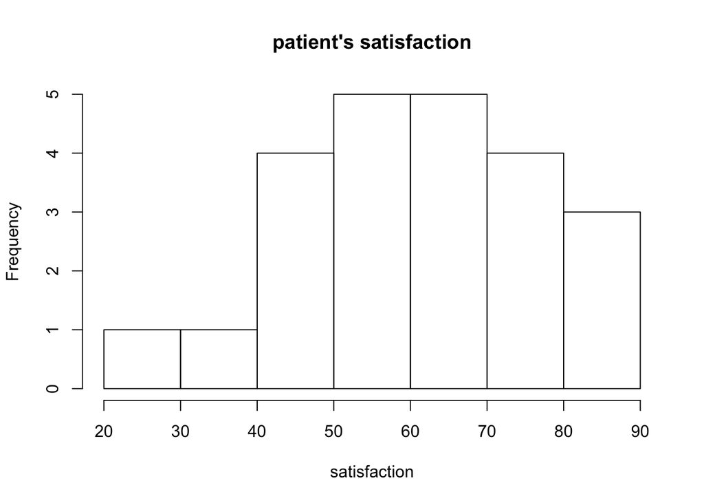

```
patients give a satisfaction score at 61.3478 on average. the max. score is 89 and the min score is 26. the standard error of the sampling distribution is 3.484924 , the distribution is lightly left skewd
```

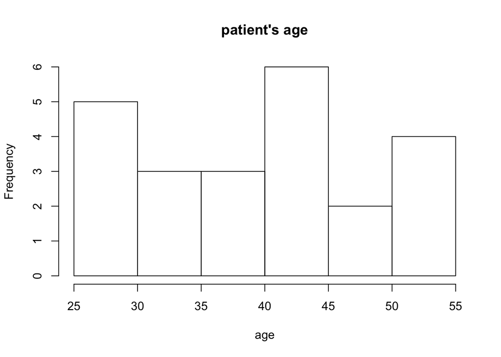

```
patients have an average age of 39.6087 year-old. the max. age is 55 and the min age is 28. the standard error of the sampling distribution is 1.765657 , the distribution doens't look like normal but is evenly distributed
```

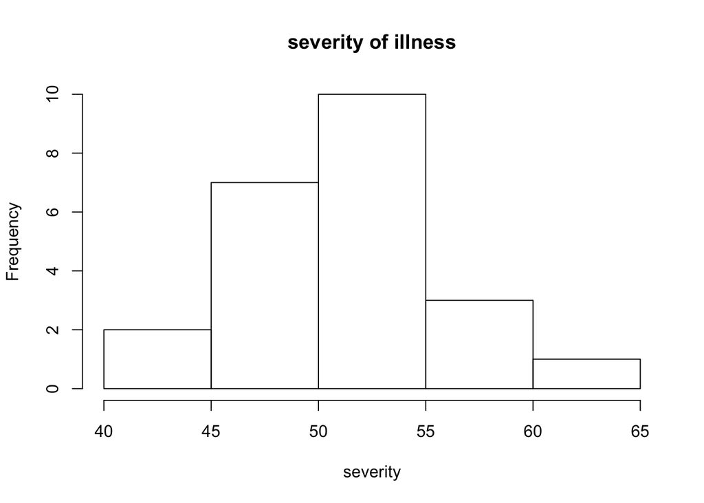

```
the mean index of severity of illness is 50.7826. the max. value is 62 and the min. value is 43. the standard error of the sampling distribution is 0.926032 , the distribution does look normal with slightly right skewness
```

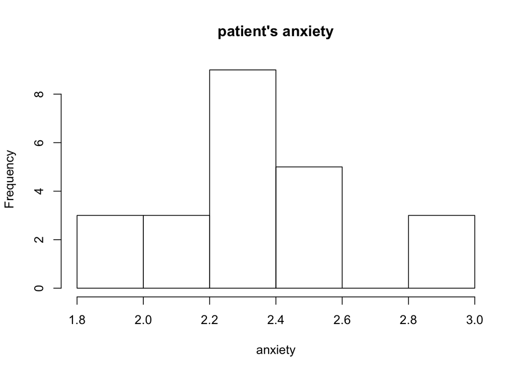

```
patients' average anxiety score is 2.29565. the max. value is 2.9 and the min. value is 1.8. the standard error of the sampling distribution is 0.063332 , the distribution does look normal but with no value sampled within anxiety score of 2.6 and 2.8
```

- **Question 2**

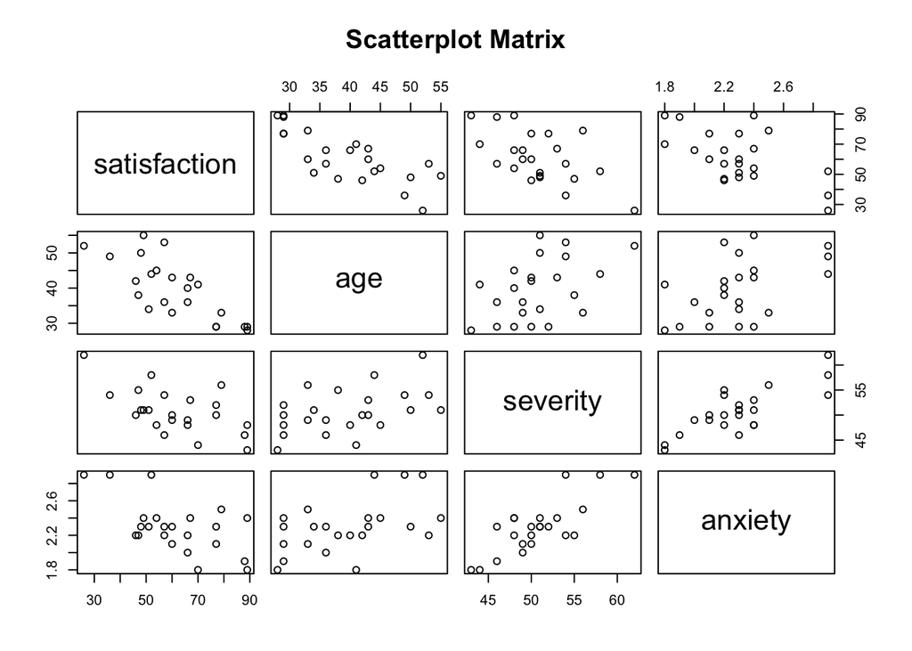

```
Correlation Matrix
```

```
             satisfaction        age   severity    anxiety
satisfaction    1.0000000 -0.7736828 -0.5874444 -0.6023105
age            -0.7736828  1.0000000  0.4666091  0.4976945
severity       -0.5874444  0.4666091  1.0000000  0.7945275
anxiety        -0.6023105  0.4976945  0.7945275  1.0000000
```

- *Comment*: From the scatterplot matrix, we see strong negative association between satisfaction (Y) and age (x1), relatively strong negative relationship between satisfaction and severity (x2), satisfaction and anxiety (x3). the correlation matrix supports these observations
- Furthermore, there is strong colinear relationship between severity and anxiety. and from correlation matrix, the predictors don’t seem to be independent from each other.
- **Question 3**

```
Call:
lm(formula = satisfaction ~ age + severity + anxiety, data = patience)

Residuals:
    Min      1Q  Median      3Q     Max
-16.954  -7.154   1.550   6.599  14.888

Coefficients:
            Estimate Std. Error t value Pr(>|t|)
(Intercept) 162.8759    25.7757   6.319 4.59e-06 ***
age          -1.2103     0.3015  -4.015  0.00074 ***
severity     -0.6659     0.8210  -0.811  0.42736
anxiety      -8.6130    12.2413  -0.704  0.49021
---
Signif. codes:  0 '***' 0.001 '**' 0.01 '*' 0.05 '.' 0.1 ' ' 1

Residual standard error: 10.29 on 19 degrees of freedom
Multiple R-squared:  0.6727,    Adjusted R-squared:  0.621
F-statistic: 13.01 on 3 and 19 DF,  p-value: 7.482e-05
```

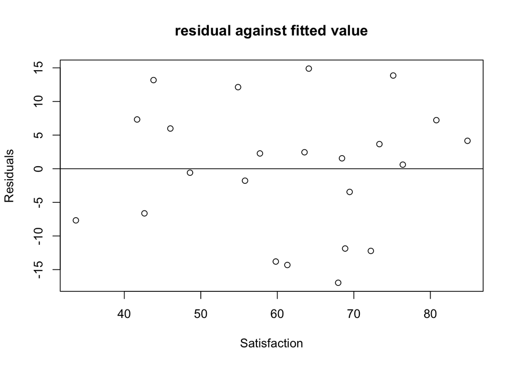

- *Comment*: The residuals “bounce randomly” around the 0 line. This suggests that the assumption that the relationship is linear is reasonable. The residuals roughly form a “horizontal band” around the 0 line. This suggests that the variances of the error terms are equal. Overall, it’s a good fit and verifies that we can use regression model to represent the data.

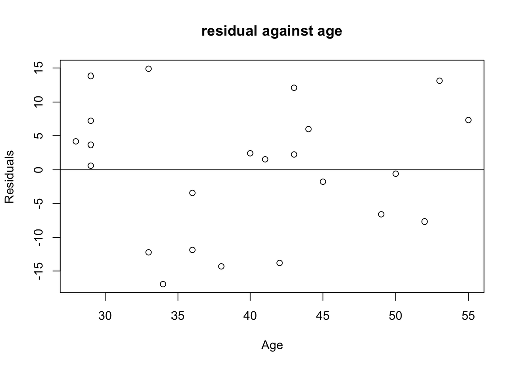

- *Comment*: The residuals “bounce randomly” around the 0 line. This suggests that the assumption that the relationship is linear is reasonable. The residuals roughly form a “horizontal band” around the 0 line. This suggests that the variances of the error terms are equal. Though the residuals keep to be centered around 5 when the age is below 30.

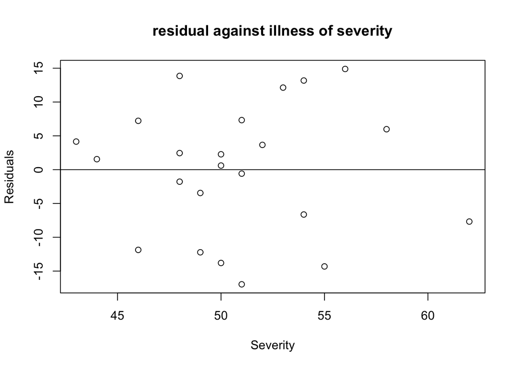

- *Comment*: The residuals “bounce randomly” around the 0 line. This suggests that the assumption that the relationship is linear is reasonable. The residuals roughly form a “horizontal band” around the 0 line. This suggests that the variances of the error terms are equal, though variance tends to be smaller on its two side.

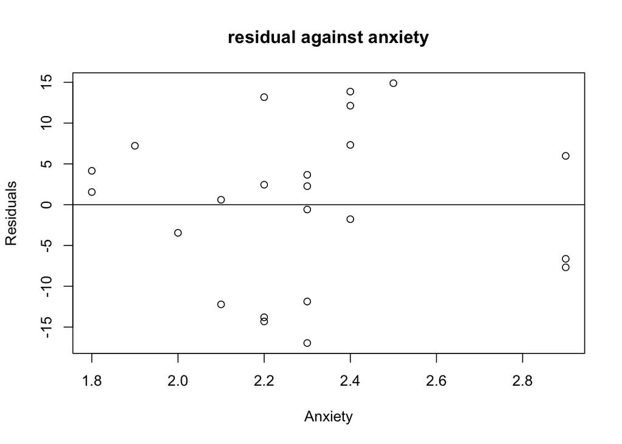

- *Comment*: The residuals “bounce randomly” around the 0 line. This suggests that the assumption that the relationship is linear is reasonable. The variance isn’t keeping constant as it’s getting smaller when approaching to its two side.

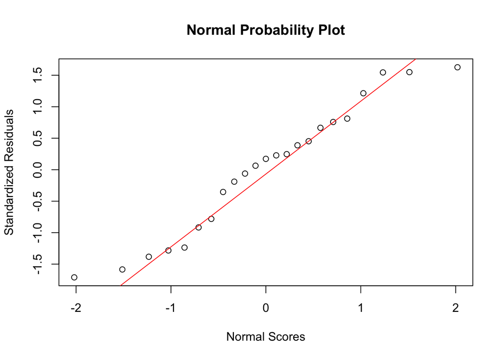

- *Comment*: The figure has flattening at the extremes for the curves. This indicates that the underlying distribution has a thin tail. thus it may not conform to a normal distribution.
- **Question 8** No, we cannot conduct a formal test for lack of fit here. Because to conduct the lack of fit test, at least we need have replicated observations at each predictors level. And none of these predictors meets the requirement.
- **Question 9**

```
            0.833 %   99.167 %
age       -2.001661 -0.4189758
severity  -2.821110  1.4892983
anxiety  -40.747613 23.5215496
```

- *Comment*: we are 95% confident that the parameter of age is between -2 and -0.42, the parameter of severity is between -2.82 and 1.49, the parameter of anxiety is between -40.75 and 23.52 in our regression model.